← Volver al repaso teórico | 📝 Taller en clase | 🏠 Inicio del curso

# Taller en clase — Simulaciones Montecarlo (VaR y ES)

## Configuración inicial

```r
if (!require("pacman")) install.packages("pacman")
pacman::p_load(tidyverse, EnvStats, scales, quantmod, xts)
options(scipen = 999)
```

# Ejercicio 1 — Simulación inversión en Dow Inc.

> “Un amigo está buscando oportunidades de inversión en algún activo de renta variable. No está dispuesto a invertir en empresas tecnológicas, por lo que ha decidido centrar su atención en **Dow Inc.**, (DOW). […] Él tiene planeado invertir un total de USD $10,000. […] Usar los retornos semanales de la acción de Dow Inc. desde el 2023-08-01 hasta el 2026-08-13 […] Cada una de las simulaciones debe de tener 10,000 iteraciones. Las simulaciones deben de iniciar con una semilla de valor **8915**. El año tiene un total de 52 semanas.”

## Datos: retornos semanales de Dow Inc. (DOW)

```r
descargar_retornos_semanales <- function(ticker) {
  precio <- quantmod::getSymbols(ticker, src = "yahoo",
                                  from = "2023-08-01", to = "2026-08-13",
                                  periodicity = "weekly",
                                  auto.assign = FALSE, warnings = FALSE)
  ajustado <- quantmod::Ad(precio)
  # diff(log(x)) en vez de TTR::ROC - bug de indexacion ya documentado en CLAUDE.md
  na.omit(diff(log(ajustado)))
}

dow_retornos <- descargar_retornos_semanales("DOW")

media_dow <- mean(dow_retornos)
sd_dow <- sd(dow_retornos)
min_dow <- min(dow_retornos)
max_dow <- max(dow_retornos)

data.frame(
  accion = "DOW", n_semanas_historia = nrow(dow_retornos),
  retorno_semanal_promedio_pct = media_dow * 100,
  desv_estandar_pct = sd_dow * 100,
  retorno_min_pct = min_dow * 100,
  retorno_max_pct = max_dow * 100
)
```

| accion | n_semanas_historia | retorno_semanal_promedio_pct | desv_estandar_pct | retorno_min_pct | retorno_max_pct |
| --- | --- | --- | --- | --- | --- |
| DOW | 158 | -0.2558966 | 4.865336 | -19.75712 | 14.28347 |

## Funciones de simulación y de riesgo

**Qué hace**: `simular_capital()` genera una matriz de retornos semanales aleatorios (10,000 filas × 52 columnas, una por escenario) y capitaliza cada fila con producto acumulado — el mismo enfoque vectorizado ya usado en `simulaciones/taller/` para 100,000 iteraciones, mucho más rápido que llamar `simulacion_activo()` fila por fila. La distribución **triangular** usa el retorno medio observado como aproximación de la moda (misma convención ya usada en el taller de Simulaciones, indicada ahí explícitamente por el enunciado). `valor_riesgo()` calcula el VaR (percentil $\alpha$ del capital final) y el ES (promedio del capital final por debajo de ese percentil), ambos expresados como pérdida en dólares.

```r
simular_capital <- function(capital_inicial, tipo, n_sim, n_periodos, media,
                             sd = NULL, minimo = NULL, maximo = NULL, moda = NULL, seed) {
  set.seed(seed)
  if (tipo == "normal") {
    retornos <- matrix(rnorm(n_sim * n_periodos, mean = media, sd = sd), nrow = n_sim, ncol = n_periodos)
  } else {
    retornos <- matrix(EnvStats::rtri(n_sim * n_periodos, min = minimo, max = maximo, mode = moda),
                        nrow = n_sim, ncol = n_periodos)
  }
  capital_inicial * apply(1 + retornos, 1, prod)
}

valor_riesgo <- function(capital_final, capital_inicial, alpha) {
  VaR_capital <- quantile(capital_final, probs = alpha)
  ES_capital <- mean(capital_final[capital_final < VaR_capital])
  data.frame(
    valor_esperado = mean(capital_final),
    valor_maximo = max(capital_final),
    ganancia_maxima = max(capital_final) - capital_inicial,
    valor_minimo = min(capital_final),
    perdida_maxima_obs = capital_inicial - min(capital_final),
    VaR = capital_inicial - VaR_capital,
    ES = capital_inicial - mean(capital_final[capital_final < VaR_capital])
  )
}
```

## Simulaciones (10,000 iteraciones, semilla 8915)

```r
capital_inicial <- 10000
n_semanas <- 52
n_sim <- 10000
semilla <- 8915
alpha <- 0.01  # 99% de confianza

final_dow_normal <- simular_capital(capital_inicial, "normal", n_sim, n_semanas,
                                     media = media_dow, sd = sd_dow, seed = semilla)
final_dow_tri <- simular_capital(capital_inicial, "triangular", n_sim, n_semanas,
                                  media = media_dow, minimo = min_dow, maximo = max_dow,
                                  moda = media_dow, seed = semilla)

tabla_dow <- bind_rows(
  cbind(distribución = "Normal", valor_riesgo(final_dow_normal, capital_inicial, alpha)),
  cbind(distribución = "Triangular", valor_riesgo(final_dow_tri, capital_inicial, alpha))
) %>% mutate(across(where(is.numeric), ~ label_dollar(accuracy = 0.01)(.x)))

tabla_dow
```

|  | distribución | valor_esperado | valor_maximo | ganancia_maxima | valor_minimo | perdida_maxima_obs | VaR | ES |
| --- | --- | --- | --- | --- | --- | --- | --- | --- |
| 1%...1 | Normal | $8,758.13 | $33,188.60 | $23,188.60 | $2,068.11 | $7,931.89 | $6,433.80 | $6,843.38 |
| 1%...2 | Triangular | $3,689.82 | $21,429.72 | $11,429.72 | $442.59 | $9,557.41 | $9,027.74 | $9,170.23 |

## Preguntas — Dow Inc.

> “1. ¿Cuál es el valor esperado de la inversión al final del año?”

**Respuesta:** con retornos normales, el valor esperado es **$8,758.13**; con retornos triangulares, **$3,689.82** — ambos por debajo del capital inicial de $10,000, porque DOW tuvo un retorno semanal promedio **negativo** (-0.26%) en el periodo histórico usado.

> “2. ¿Cuál es el valor máximo de la inversión al final del año? ¿Cuánto representa en ganancias?”

**Respuesta:** el máximo con la normal es **$33,188.60** ($23,188.60 de ganancia); con la triangular, **$21,429.72** ($11,429.72 de ganancia).

> “3. ¿Cuál es el valor mínimo de la inversión al final del año? ¿Cuánto representa en pérdidas?”

**Respuesta:** el mínimo con la normal es **$2,068.11** ($7,931.89 de pérdida); con la triangular, **$442.59** ($9,557.41 de pérdida) — casi la totalidad del capital, el peor de los 10,000 escenarios simulados.

> “4. ¿Cuál es la máxima pérdida posible con una confianza del 99 %?”

**Respuesta (VaR al 99%):**

- **Normal:** la pérdida máxima de la inversión, con un 99% de confianza en el año, es de USD $6,433.80. Hay una probabilidad del 1% de que las pérdidas de la inversión sean mayores a USD $6,433.80.
- **Triangular:** la pérdida máxima de la inversión, con un 99% de confianza en el año, es de USD $9,027.74. Hay una probabilidad del 1% de que las pérdidas de la inversión sean mayores a USD $9,027.74.

> “5. ¿Cuánto es el valor esperado a perder de la inversión en el 1 % de los casos?”

**Respuesta (ES al 99%):**

- **Normal:** la pérdida esperada al 1% en el año es de USD $6,843.38.
- **Triangular:** la pérdida esperada al 1% en el año es de USD $9,170.23.

En ambos casos, más severo que el VaR de la pregunta anterior, como debe ser.

> “6. ¿Cuál distribución genera mejores resultados, considerando una política de aversión al riesgo?”

**Respuesta:** la **normal domina en las dos dimensiones que le importan a alguien averso al riesgo**: valor esperado más alto ($8,758.13 vs. $3,689.82) *y* VaR/ES más bajos (menos pérdida potencial). No hay disyuntiva entre retorno y riesgo acá — la normal es simplemente mejor en ambos frentes para DOW en este periodo, así que bajo cualquier política de aversión al riesgo se prefiere.

## Repetición con Eli Lilly and Company (LLY) — pregunta 7

> “7. Repite el ejercicio usando la acción de **Eli Lilly and Company**, (LLY).”

```r
lly_retornos <- descargar_retornos_semanales("LLY")

media_lly <- mean(lly_retornos)
sd_lly <- sd(lly_retornos)
min_lly <- min(lly_retornos)
max_lly <- max(lly_retornos)

final_lly_normal <- simular_capital(capital_inicial, "normal", n_sim, n_semanas,
                                     media = media_lly, sd = sd_lly, seed = semilla)
final_lly_tri <- simular_capital(capital_inicial, "triangular", n_sim, n_semanas,
                                  media = media_lly, minimo = min_lly, maximo = max_lly,
                                  moda = media_lly, seed = semilla)

tabla_lly <- bind_rows(
  cbind(distribución = "Normal", valor_riesgo(final_lly_normal, capital_inicial, alpha)),
  cbind(distribución = "Triangular", valor_riesgo(final_lly_tri, capital_inicial, alpha))
) %>% mutate(across(where(is.numeric), ~ label_dollar(accuracy = 0.01)(.x)))

tabla_lly
```

|  | distribución | valor_esperado | valor_maximo | ganancia_maxima | valor_minimo | perdida_maxima_obs | VaR | ES |
| --- | --- | --- | --- | --- | --- | --- | --- | --- |
| 1%...1 | Normal | $13,991.06 | $56,528.07 | $46,528.07 | $3,053.18 | $6,946.82 | $4,585.39 | $5,234.79 |
| 1%...2 | Triangular | $6,006.94 | $37,554.80 | $27,554.80 | $650.99 | $9,349.01 | $8,518.89 | $8,744.36 |

> “2. ¿Cuál es el valor máximo de la inversión al final del año? ¿Cuánto representa en ganancias?”

**Respuesta:** el máximo con la normal es **$56,528.07** ($46,528.07 de ganancia); con la triangular, **$37,554.80** ($27,554.80 de ganancia).

> “3. ¿Cuál es el valor mínimo de la inversión al final del año? ¿Cuánto representa en pérdidas?”

**Respuesta:** el mínimo con la normal es **$3,053.18** ($6,946.82 de pérdida); con la triangular, **$650.99** ($9,349.01 de pérdida).

> “4. ¿Cuál es la máxima pérdida posible con una confianza del 99 %?”

**Respuesta (VaR al 99%):**

- **Normal:** la pérdida máxima de la inversión, con un 99% de confianza en el año, es de USD $4,585.39. Hay una probabilidad del 1% de que las pérdidas de la inversión sean mayores a USD $4,585.39.
- **Triangular:** la pérdida máxima de la inversión, con un 99% de confianza en el año, es de USD $8,518.89. Hay una probabilidad del 1% de que las pérdidas de la inversión sean mayores a USD $8,518.89.

> “5. ¿Cuánto es el valor esperado a perder de la inversión en el 1 % de los casos?”

**Respuesta (ES al 99%):**

- **Normal:** la pérdida esperada al 1% en el año es de USD $5,234.79.
- **Triangular:** la pérdida esperada al 1% en el año es de USD $8,744.36.

> “6. ¿Cuál distribución genera mejores resultados, considerando una política de aversión al riesgo?”

**Respuesta:** igual que con DOW, la **normal vuelve a dominar** a la triangular en valor esperado y en VaR/ES — mismo patrón, dos acciones distintas: acá, la triangular (acotada por el peor/mejor retorno histórico observado) termina con más riesgo de cola que la normal, no menos, porque su forma comprime la masa de probabilidad lejos de la moda hacia los extremos del rango observado al compuesto en 52 semanas.

# Ejercicio 2 — Elección de la mejor inversión

> “¡Te has ganado una rifa de COP $10,000,000! […] Has decidido invertir tus ganancias ocasionales en algún activo de renta variable a un periodo de un año. Tienes 3 opciones […] Utilizando simulaciones con 100,000 iteraciones calcula para cada posible inversión: 1. El valor esperado de la inversión al final del año. 2. El valor en riesgo con una confianza del 99 %. 3. La pérdida esperada en el 1 % de los casos.”

> “a. Un activo cuyos retornos son anuales y siguen una distribución normal con un retorno medio de 8 % y una desviación estándar de 15 %.”

> “b. Un activo con retornos mensuales que siguen una distribución triangular con un mínimo de -13.84 %, un máximo de 21.49 % y un retorno medio de 4.76 %.”

> “c. Un activo con retornos diarios que siguen una distribución normal con un retorno medio de 0.102 % y una desviación estándar de 1.79 %.”

**Nota de implementación**: para el activo (c), “un año” se toma como 252 días hábiles (convención estándar en finanzas para retornos diarios). Para el (b), se compone mensualmente 12 veces; para el (a), un solo periodo anual.

```r
capital_p2 <- 10000000  # COP
n_sim_p2 <- 100000

final_a <- simular_capital(capital_p2, "normal", n_sim_p2, 1,
                            media = 0.08, sd = 0.15, seed = semilla)
final_b <- simular_capital(capital_p2, "triangular", n_sim_p2, 12,
                            media = 0.0476, minimo = -0.1384, maximo = 0.2149,
                            moda = 0.0476, seed = semilla)
final_c <- simular_capital(capital_p2, "normal", n_sim_p2, 252,
                            media = 0.00102, sd = 0.0179, seed = semilla)

fmt_cop <- label_dollar(prefix = "COP $", big.mark = ".", decimal.mark = ",", accuracy = 1)

tabla_p2 <- bind_rows(
  cbind(activo = "a) Normal, anual", valor_riesgo(final_a, capital_p2, alpha)),
  cbind(activo = "b) Triangular, mensual x12", valor_riesgo(final_b, capital_p2, alpha)),
  cbind(activo = "c) Normal, diaria x252", valor_riesgo(final_c, capital_p2, alpha))
) %>%
  select(activo, valor_esperado, VaR, ES) %>%
  mutate(across(where(is.numeric), fmt_cop))

tabla_p2
```

|  | activo | valor_esperado | VaR | ES |
| --- | --- | --- | --- | --- |
| 1%...1 | a) Normal, anual | COP $10.799.202 | COP $2.694.485 | COP $3.224.843 |
| 1%...2 | b) Triangular, mensual x12 | COP $16.267.740 | COP $1.071.737 | COP $1.785.090 |
| 1%...3 | c) Normal, diaria x252 | COP $12.924.544 | COP $3.586.716 | COP $4.172.417 |

**Respuesta:**

**1. Valor esperado:** (a) COP $10.799.202, (b) COP $16.267.740, (c) COP $12.924.544.

**2. VaR al 99%:**

- **a)** La pérdida máxima de la inversión, con un 99% de confianza en el año, es de COP $2.694.485. Hay una probabilidad del 1% de que las pérdidas de la inversión sean mayores a COP $2.694.485.
- **b)** La pérdida máxima de la inversión, con un 99% de confianza en el año, es de COP $1.071.737. Hay una probabilidad del 1% de que las pérdidas de la inversión sean mayores a COP $1.071.737.
- **c)** La pérdida máxima de la inversión, con un 99% de confianza en el año, es de COP $3.586.716. Hay una probabilidad del 1% de que las pérdidas de la inversión sean mayores a COP $3.586.716.

**3. ES en el 1% de los casos:**

- **a)** La pérdida esperada al 1% en el año es de COP $3.224.843.
- **b)** La pérdida esperada al 1% en el año es de COP $1.785.090.
- **c)** La pérdida esperada al 1% en el año es de COP $4.172.417.

## Recomendación

La opción **b) (triangular, retornos mensuales)** domina a las otras dos en las tres métricas a la vez: **mayor valor esperado** y **menor VaR y ES** (menos pérdida potencial en el peor 1% de escenarios). No hay que sacrificar retorno por seguridad ni viceversa — b) es simplemente mejor en ambos frentes, así que es la elección clara para invertir el premio de la rifa, sin importar qué tan averso al riesgo sea el inversionista.

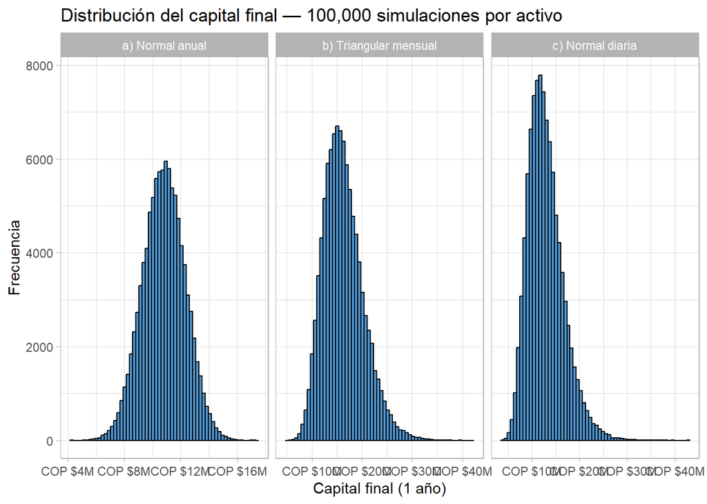

```r
datos_p2 <- bind_rows(
  data.frame(capital_final = final_a, activo = "a) Normal anual"),
  data.frame(capital_final = final_b, activo = "b) Triangular mensual"),
  data.frame(capital_final = final_c, activo = "c) Normal diaria")
)

ggplot(datos_p2, aes(x = capital_final)) +
  geom_histogram(color = "black", fill = "steelblue3", bins = 60) +
  facet_wrap(~activo, scales = "free_x") +
  theme_light() +
  scale_x_continuous(labels = label_dollar(scale = 1e-6, suffix = "M", prefix = "COP $")) +
  labs(x = "Capital final (1 año)", y = "Frecuencia",
       title = "Distribución del capital final — 100,000 simulaciones por activo")
```